# Challenge 7

- Show All Code
- Hide All Code
- View Source

Author

Kailyn Kragas

## Packages & Dataset

```r
library(tidyverse)

fishData <- read_csv(here::here("Labs",
                                "Lab 7",
                                "BlackfootFish.csv"))
```

## **4.1 Part 1**

```r
removeOutlier <- function(col, min, max) {

  stopifnot(is.vector(col),
            is.numeric(min),
            is.numeric(max))

  new <- ifelse(col %in% c(min:max), col, NA)

  return(new)

}
```

```r
fishData <- fishData |>
  mutate(length = removeOutlier(length, 200, 770),
         weight = removeOutlier(weight, 140, 7000))

# https://www.dec.ny.gov/outdoor/9222.html
# https://dnr.maryland.gov/education/Documents/RainbowTrout.pdf
```

Using the first source in the comment box, I have made an assumption for the range of length to be from 7 *(supposed to be 9 but rounded off 240 mm to 200mm)* to 30 inches. This is also so we can also take the younger and smaller trouts into account. The source does not give equivalent weight measurements for 7 to 11.5 inch trouts, so I have used the 10 - 11.5 inch weight measurements of the Brook Trout as a basis for my Trout weight. It also appears to increase by an ounce for every .5 inch increase so I have decreased an by an ounce for every .5 inch decrease. My minimum weight for a 7 inch trout is 5 oz. Other sources claim trouts to grow as large as 30 inches and as heavy as 16 pounds, which is what I have used to set my maximum values.

## **4.2 Part 2**

```r
conditionIndex <- function(weight, length) {

  stopifnot(is.numeric(weight),
            is.numeric(length))

  result <- (weight / length ^ 3) * 100

  return(result)
}
```

```r
newData <- fishData |>
  mutate(length = removeOutlier(length, 200, 770),
         weight = removeOutlier(weight, 140, 7000),
         condition = conditionIndex(weight, length))
```

## **4.3 Part 3**

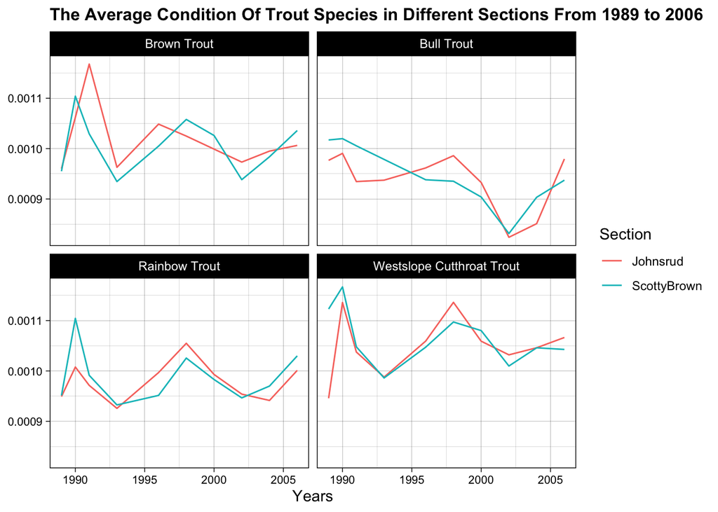

```r
newData |> mutate(species = case_when(species == "RBT" ~ "Rainbow",
                                      species == "WCT" ~ "Westslope Cutthroat",
                                      TRUE ~ species),
                  species = str_c(species, " ", "Trout" )) |>
  group_by(year, species, section) |>
  summarize(meanCondition = mean(condition, na.rm = TRUE)) |>
  ggplot(mapping = aes(x = year, y = meanCondition, color = section)) +
  geom_line() +
  facet_wrap(~species) +
  theme_linedraw() +
  labs(title = "The Average Condition Of Trout Species in Different Sections From 1989 to 2006",
       x = "Years",
      color = "Section") +
  theme(axis.title.y = element_blank(),
        plot.title = element_text(face = "bold",
                                  size = 12),
        axis.text = element_text(size = 8))
```